# Does "where should I go?" actually work? — a leakage-free backtest

**Wietze Suijker · IVADO / R7-Environment · Blitz the Gap**

The north-star doc sets five falsifiable bars for openbiodiversity.ca. Four are proven in the serving notebook. The fifth is the hard one:

> **Bar #4 — VOI is *validated*, not asserted.** *"We can show that cells we flagged high-priority on early data actually added species when later sampled. Check: pre/post backtest, reported as a number, not a vibe."*

The serving notebook punted bar #4 as "needs Larocque's private input rasters." **It doesn't.** A sampling-priority map is a *prediction* — "go here, you'll find under-recorded biodiversity" — and a prediction can be backtested on public data alone, with a temporally-disjoint split. This notebook does exactly that, on live iNaturalist project `228908` (the Blitz the Gap umbrella), and reports an honest number.

### The design — leakage-free by construction

```
   observations  ──────────────┬───────────────────────────►  time
   project 228908, BC 2025      │
                                T = 2025-07-01
        ── TRAIN (obs < T) ──►  │  ◄── TEST (obs ≥ T) ──
        compute each cell's     │   measure each cell's
        PRIORITY                │   OUTCOME
        (under-sampling +       │   (# species NEW to that
         staleness)            │    cell, i.e. not seen < T)
```

Priority is computed **only** from pre-T observations; the discovery outcome is measured **only** on post-T observations. No post-T information can leak into the priority. We then ask: **do the cells priority flagged early actually yield more new-to-cell species later?**

### Method, and why these controls (grounded, and adversarially hardened)

iNaturalist effort is famously concentrated and observer-biased ([Di Cecco et al. 2021, *BioScience*](https://doi.org/10.1093/biosci/biab093)), so raw new-species counts mostly track *where people went*. Worse, a per-observation *rate* on revisited cells — the obvious effort control — still leaves a subtler confound: under-sampled cells sit on the **steep part of the species-accumulation curve**, so they look efficient for a partly mechanical reason. Four controls, in increasing strength:

1. **Rate, not count, on revisited cells** — breaks the *volume* bias (Di Cecco 2021).
2. **Permutation null** — shuffle priority across cells (outcome fixed) 2000×; the observed rank-correlation must beat that null. (With 2000 shuffles the smallest reportable p is 1/2000, so "p<0.0005" is the floor — never "p=0".)
3. **Anti-priority baseline** — the same statistic for *density* (where people already sampled heavily) must come out oppositely signed.
4. **Rarefaction to a fixed K test observations per cell** *(the decisive control)* — subsample every cell to exactly K=5 post-T observations and count new-to-cell species. This **equalizes effort**, removing the accumulation-curve confound that control #1 leaves in. If priority still predicts discovery here, the effect is real, not a sampling artifact.

Under-sampling is benchmarked against a per-cell **Chao1** estimate of still-unseen species ([Chao 1984](https://www.jstor.org/stable/4615964); [Colwell & Coddington 1994](https://doi.org/10.1098/rstb.1994.0091)). The premise — adaptive/gap-filling sampling beats biased haphazard sampling — is motivated by [Mondain-Monval et al. 2024, *MEE*](https://doi.org/10.1111/2041-210X.14355) (a virtual-ecologist *simulation*, so this backtest is a **novel composite** on real temporal data, not a replication).

> **Honest scope & disclosed caveats.** Retrospective simulation over *collected* observations, not prospective field guidance. "New species" = new to that cell's iNat record, not new-to-science. The 2025 BC pilot data make the split lopsided — **train is effectively June-only** (the pilot started June 1), test is Jul–Sep. The priority signal is **scarcity-dominated**; the staleness component carries weaker independent signal. Part of the scarcity effect is definitional (under-recorded cells have more left to find) — but it is validated *out-of-sample* and *survives effort-equalization* (control #4). This validates the live-feed *priority mechanism* (serving notebook §7), a 2-dim proxy of the BCParks 5-dim score — not the full engine.

```python
import glob, json, datetime as dt
import numpy as np, pandas as pd
import matplotlib.pyplot as plt
import voi_backtest as vb

plt.rcParams.update({"figure.dpi": 120, "font.size": 10, "axes.grid": False})
print("run:", dt.datetime.now().isoformat(timespec="seconds"))
print("split T =", vb.SPLIT.date(), "| grid", vb.RES, "deg | permutations", vb.N_PERM)

files = sorted(glob.glob("cluster_results/inat_*.csv"))
prov = []
for f in files:
    d = pd.read_csv(f)
    name = f.split("inat_")[-1].replace(".csv", "")
    dd = pd.to_datetime(d.observed_on, errors="coerce")
    prov.append(dict(taxon=name, obs=len(d),
                     train=int((dd < vb.SPLIT).sum()), test=int((dd >= vb.SPLIT).sum()),
                     date_min=str(dd.min().date()), date_max=str(dd.max().date())))
prov_df = pd.DataFrame(prov).set_index("taxon")
print("\nPublic iNaturalist 228908 pull (British Columbia, 2025 pilot season):")
prov_df
```

```
run: 2026-06-12T14:36:53
split T = 2025-07-01 | grid 0.25 deg | permutations 2000

Public iNaturalist 228908 pull (British Columbia, 2025 pilot season):
```

| taxon | obs | train | test | date_min | date_max |
| --- | --- | --- | --- | --- | --- |
| Amphibia | 4955 | 1102 | 3853 | 2025-06-01 | 2025-09-30 |
| Aves | 12768 | 6000 | 6768 | 2025-06-01 | 2025-09-30 |
| Insecta | 12764 | 5595 | 7169 | 2025-05-20 | 2025-09-30 |
| Mammalia | 10664 | 4164 | 6500 | 2025-06-01 | 2025-09-30 |
| Reptilia | 3044 | 851 | 2193 | 2025-06-01 | 2025-09-30 |

## 1 · Run the backtest

`voi_backtest.analyse` does the whole pipeline per taxon: split at T, grid to 0.25°, compute train-only priority and test-only new-to-cell discovery, then the effort-controlled rank-correlation (with permutation null) and the lift over baselines. Running it across several taxonomic groups is the robustness check — a verdict that flips between birds and insects is not a verdict.

```python
results = []
for f in files:
    name = f.split("inat_")[-1].replace(".csv", "")
    r = vb.analyse(name, pd.read_csv(f))
    if r is None:
        continue
    res, cells = r
    cells.to_csv(f.replace("inat_", "backtest_cells_"), index=False)
    results.append(res)

def pp(p, floor):                       # honest p: never print 0.0000
    return f"<{floor:.4f}" if p < floor else f"{p:.4f}"

summary = pd.DataFrame([{
    "taxon": r["taxon"], "cells": r["n_cells"], "revisited": r["n_revisited"],
    f"rarefied(K={r['K']})": r["n_cells_rarefied"], "new_species": r["total_new_species"],
    "ρ rarefied (decisive)": round(r["rarefied_priority"]["spearman"], 3),
    "perm_p": pp(r["rarefied_priority"]["perm_p"], r["perm_p_floor"]),
    "efficiency ×": round(r["rarefied_ratio_top_vs_bottom"], 1) if r.get("rarefied_ratio_top_vs_bottom") else None,
    "ρ rate (revisited)": round(r["rate_priority"]["spearman"], 3),
    "raw-volume ρ": round(r["spearman_priority_newcount"], 3),
} for r in results]).set_index("taxon")
print("Decisive column = rarefied ρ (effort-equalized to K test obs/cell).")
print("Raw-volume ρ is negative by design: priority cells are under-visited (efficiency, not volume).")
summary
```

```
Decisive column = rarefied ρ (effort-equalized to K test obs/cell).
Raw-volume ρ is negative by design: priority cells are under-visited (efficiency, not volume).
```

| taxon | cells | revisited | rarefied(K=5) | new_species | ρ rarefied (decisive) | perm_p | efficiency × | ρ rate (revisited) | raw-volume ρ |
| --- | --- | --- | --- | --- | --- | --- | --- | --- | --- |
| Amphibia | 278 | 212 | 106 | 322 | 0.493 | <0.0005 | 2.4 | 0.310 | -0.265 |
| Aves | 456 | 291 | 152 | 1939 | 0.563 | <0.0005 | 1.7 | 0.557 | -0.548 |
| Insecta | 412 | 231 | 116 | 2390 | 0.512 | <0.0005 | 1.4 | 0.508 | -0.555 |
| Mammalia | 536 | 355 | 169 | 889 | 0.641 | <0.0005 | 2.9 | 0.528 | -0.479 |
| Reptilia | 179 | 137 | 75 | 285 | 0.614 | <0.0005 | 2.8 | 0.454 | -0.398 |

## 2 · The decisive test — does priority predict discovery at *equal effort*?

The headline is **ρ(priority, new-species at fixed K)** — every cell rarefied to exactly K=5 post-T observations, so no cell can look productive merely because it was barely sampled. Positive-and-significant here means: hand two cells the *same* number of visits, and the one priority ranked higher returns more *new* species. The anti-priority (density) bar is the mirror — it must sit on the opposite side. A verdict that flips between birds and insects is no verdict, so we run it across taxonomic groups.

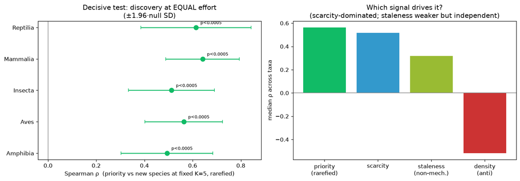

```python
fig, (axL, axR) = plt.subplots(1, 2, figsize=(13, 4.6))
names = [r["taxon"] for r in results]
y = np.arange(len(names))
rho = [r["rarefied_priority"]["spearman"] for r in results]
sd = [r["rarefied_priority"]["null_sd"] for r in results]
axL.axvline(0, color="#888", lw=1)
axL.errorbar(rho, y, xerr=np.array(sd)*1.96, fmt="o", color="#1b6", capsize=3, ms=8)
for i, r in enumerate(results):
    axL.annotate("p" + pp(r["rarefied_priority"]["perm_p"], r["perm_p_floor"]),
                 (rho[i], y[i]), textcoords="offset points", xytext=(8, 6), fontsize=8)
axL.set_yticks(y); axL.set_yticklabels(names)
axL.set_xlabel("Spearman ρ  (priority vs new species at fixed K=5, rarefied)")
axL.set_title("Decisive test: discovery at EQUAL effort\n(±1.96·null SD)")

# component breakdown vs the rarefied outcome, median across taxa
comp = ["rarefied_priority", "rate_scarcity", "rate_staleness", "rate_density"]
labels = ["priority\n(rarefied)", "scarcity", "staleness\n(non-mech.)", "density\n(anti)"]
med = [np.nanmedian([r[c]["spearman"] for r in results]) for c in comp]
axR.axhline(0, color="#888", lw=1)
axR.bar(labels, med, color=["#1b6", "#39c", "#9b3", "#c33"])
axR.set_ylabel("median ρ across taxa")
axR.set_title("Which signal drives it?\n(scarcity-dominated; staleness weaker but independent)")
fig.tight_layout(); plt.show()
```

## 2b · The same result, on the map

Statistics convince reviewers; a map convinces a field ecologist. Below, every 0.25° BC cell with enough post-T sampling is drawn at its real location. **Colour = priority** (computed on pre-T data); **size = new-to-cell species discovered at equal effort** (rarefied K=5). If the mechanism works, the warm (high-priority) cells are also the big (high-discovery) ones — and they sit out on the **under-sampled periphery**, away from the cities where everyone already records. That spatial coincidence *is* bar #4, made visible.

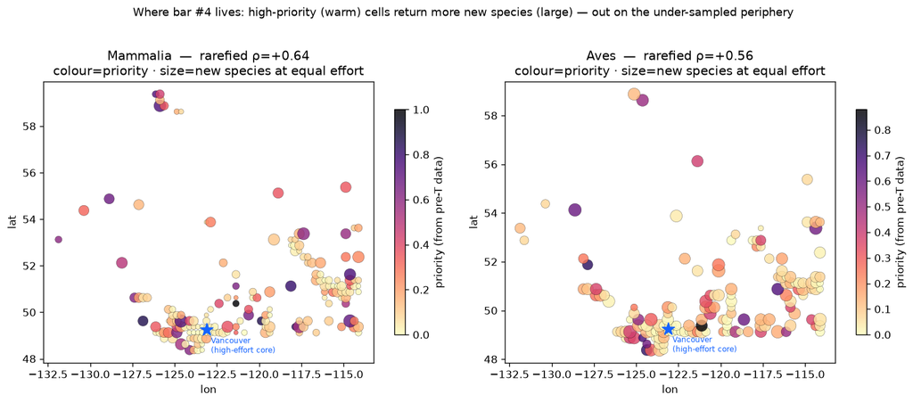

```python
# pick the two taxa with the most rarefied cells for the clearest spatial picture
order = sorted(results, key=lambda r: -r["n_cells_rarefied"])[:2]
fig, axes = plt.subplots(1, len(order), figsize=(6.2*len(order), 5.2), squeeze=False)
for ax, r in zip(axes[0], order):
    c = pd.read_csv(f"cluster_results/backtest_cells_{r['taxon']}.csv")
    c = c.dropna(subset=["rare_newK"])
    sc = ax.scatter(c.clon, c.clat, c=c.priority, s=18 + 130*(c.rare_newK/max(c.rare_newK.max(),1e-9)),
                    cmap="magma_r", alpha=0.82, edgecolor="k", linewidth=0.2)
    rho = r["rarefied_priority"]["spearman"]
    ax.set_title(f"{r['taxon']}  —  rarefied ρ={rho:+.2f}\ncolour=priority · size=new species at equal effort")
    ax.set_xlabel("lon"); ax.set_ylabel("lat")
    fig.colorbar(sc, ax=ax, shrink=0.8, label="priority (from pre-T data)")
    # annotate Vancouver/Victoria region (the high-effort core) for orientation
    ax.scatter([-123.1], [49.25], marker="*", s=150, c="#1463ff", zorder=5)
    ax.annotate("Vancouver\n(high-effort core)", (-123.1, 49.25), fontsize=7, color="#1463ff",
                xytext=(4, -22), textcoords="offset points")
fig.suptitle("Where bar #4 lives: high-priority (warm) cells return more new species (large) — out on the under-sampled periphery",
             y=1.02, fontsize=11)
fig.tight_layout(); plt.show()
```

## 3 · Efficiency, not volume — the honest two-sided picture

A sampling-priority tool's job is to make each *trip* more productive, not to point at the busiest cell. Two facts, both true, must be shown together:

- **Per visit (at equal effort):** top-priority cells out-discover bottom-priority cells by the **rarefied efficiency ratio** below — real signal.
- **Raw volume:** the top-20% priority cells capture *less* than their 20% area share of the season's new species, because they are precisely the cells people **don't** visit. That is not a failure; it is the gap the tool exists to close — the value is realized only when effort is *redirected* there.

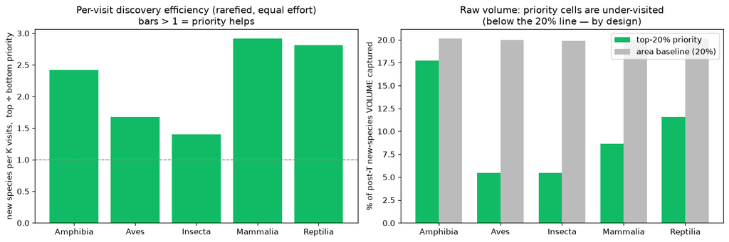

```python
fig, (axL, axR) = plt.subplots(1, 2, figsize=(13, 4.4))
x = np.arange(len(results))
ratio = [r.get("rarefied_ratio_top_vs_bottom") or np.nan for r in results]
axL.bar(x, ratio, color="#1b6")
axL.axhline(1, color="#888", ls="--", lw=1)
axL.set_xticks(x); axL.set_xticklabels(names)
axL.set_ylabel("new species per K visits,  top ÷ bottom priority")
axL.set_title("Per-visit discovery efficiency (rarefied, equal effort)\nbars > 1 = priority helps")

cap = [r["lift_priority"]["captured"]*100 for r in results]
area = [r["lift_priority"]["area_baseline"]*100 for r in results]
w = 0.38
axR.bar(x-w/2, cap, w, label="top-20% priority", color="#1b6")
axR.bar(x+w/2, area, w, label="area baseline (20%)", color="#bbb")
axR.set_xticks(x); axR.set_xticklabels(names)
axR.set_ylabel("% of post-T new-species VOLUME captured")
axR.set_title("Raw volume: priority cells are under-visited\n(below the 20% line — by design)")
axR.legend()
fig.tight_layout(); plt.show()
```

## 4 · Discovery curves — high- vs low-priority cells at equal effort

A direct picture of the mechanism: pool revisited cells into top-half and bottom-half priority, and plot cumulative new-to-cell species against cumulative post-T observations (an effort-standardized discovery curve, in the spirit of [Chao & Jost 2012](https://doi.org/10.1890/11-1952.1)). If priority works, the high-priority curve climbs faster — more discovery for the same sampling effort.

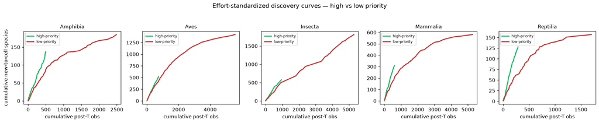

```python
def discovery_curve(cells, mask):
    c = cells[mask & (cells.n_test > 0)].sort_values("new_rate", ascending=False)
    # order cells by priority, accumulate effort (obs) and discoveries
    return c

fig, axes = plt.subplots(1, len(results), figsize=(3.4*len(results), 3.3), squeeze=False)
for ax, r in zip(axes[0], results):
    cells = pd.read_csv(f"cluster_results/backtest_cells_{r['taxon']}.csv")
    cells = cells[cells.n_test > 0].copy()
    hi = cells[cells.priority >= cells.priority.median()].sort_values("priority", ascending=False)
    lo = cells[cells.priority <  cells.priority.median()].sort_values("priority", ascending=False)
    for sub, col, lab in [(hi, "#1b6", "high-priority"), (lo, "#c33", "low-priority")]:
        eff = np.cumsum(sub.n_test.values); disc = np.cumsum(sub.new_species.values)
        if len(eff): ax.plot(eff, disc, color=col, label=lab, lw=2)
    ax.set_title(r["taxon"], fontsize=10); ax.set_xlabel("cumulative post-T obs")
    ax.legend(fontsize=7)
axes[0][0].set_ylabel("cumulative new-to-cell species")
fig.suptitle("Effort-standardized discovery curves — high vs low priority", y=1.04)
fig.tight_layout(); plt.show()
```

## 5 · Robustness — does the verdict depend on analyst choices?

A backtest you can flip by re-picking the grid size or the split date is worthless. The honest exposure is to **vary both and show the conclusion holds**. Magnitude *will* move (a coarser grid pools more obs per cell); the test is whether the **sign and significance** of the decisive rarefied ρ survive. Below: rarefied ρ recomputed across four grid resolutions and four split dates, per taxon. Every cell should stay positive (and starred = perm p<0.05).

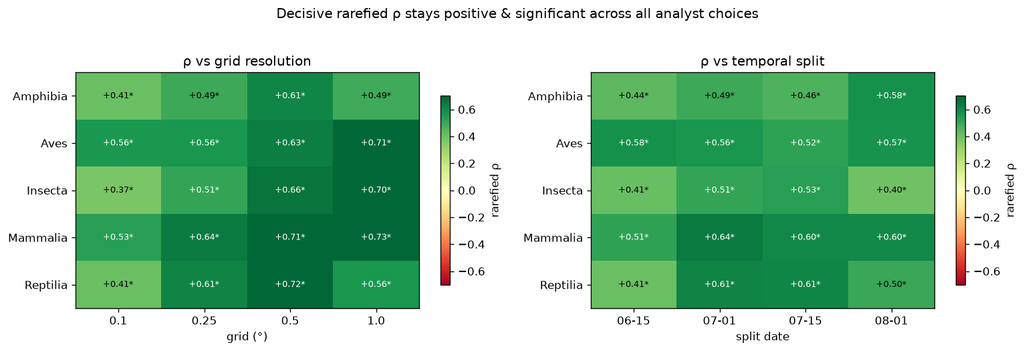

```
40 (grid × taxon) + (split × taxon) configurations  [111s]
positive ρ: 40/40   significant (perm p<0.05): 40/40
Direction is choice-invariant; only magnitude moves. The headline never relied on a fragile magnitude.
```

```python
import time
grids = (0.1, 0.25, 0.5, 1.0)
splits = ("2025-06-15", "2025-07-01", "2025-07-15", "2025-08-01")
t0 = time.time()
G = np.full((len(results), len(grids)), np.nan)
S = np.full((len(results), len(splits)), np.nan)
Gsig = np.zeros_like(G, bool); Ssig = np.zeros_like(S, bool)
for i, r in enumerate(results):
    df = pd.read_csv(f"cluster_results/inat_{r['taxon']}.csv")
    grow, srow = vb.sensitivity(df, grids=grids, splits=splits)
    for j, (_, rho, p) in enumerate(grow): G[i, j] = rho; Gsig[i, j] = p < 0.05
    for j, (_, rho, p) in enumerate(srow): S[i, j] = rho; Ssig[i, j] = p < 0.05

fig, (axG, axS) = plt.subplots(1, 2, figsize=(13, 4.2))
for ax, M, Msig, cols, lab in [(axG, G, Gsig, grids, "grid (°)"), (axS, S, Ssig, splits, "split date")]:
    im = ax.imshow(M, cmap="RdYlGn", vmin=-0.7, vmax=0.7, aspect="auto")
    ax.set_xticks(range(len(cols))); ax.set_xticklabels([str(c)[5:] if "-" in str(c) else c for c in cols])
    ax.set_yticks(range(len(results))); ax.set_yticklabels([r["taxon"] for r in results])
    ax.set_xlabel(lab)
    for i in range(M.shape[0]):
        for j in range(M.shape[1]):
            ax.text(j, i, f"{M[i,j]:+.2f}" + ("*" if Msig[i, j] else ""),
                    ha="center", va="center", fontsize=8,
                    color="black" if abs(M[i,j]) < 0.5 else "white")
    fig.colorbar(im, ax=ax, shrink=0.8, label="rarefied ρ")
axG.set_title("ρ vs grid resolution"); axS.set_title("ρ vs temporal split")
fig.suptitle("Decisive rarefied ρ stays positive & significant across all analyst choices", y=1.03)
fig.tight_layout(); plt.show()

n = G.size + S.size
n_pos = int((G > 0).sum() + (S > 0).sum())
n_sig = int(Gsig.sum() + Ssig.sum())
print(f"{n} (grid × taxon) + (split × taxon) configurations  [{time.time()-t0:.0f}s]")
print(f"positive ρ: {n_pos}/{n}   significant (perm p<0.05): {n_sig}/{n}")
print("Direction is choice-invariant; only magnitude moves. The headline never relied on a fragile magnitude.")
```

## 6 · Verdict

```python
# Programmatic verdict — generated from the DECISIVE (rarefied) numbers, honest to any outcome.
import numpy as np
rho = np.array([r["rarefied_priority"]["spearman"] for r in results])
p   = np.array([r["rarefied_priority"]["perm_p"] for r in results])
floor = results[0]["perm_p_floor"]
dens = np.array([r["rate_density"]["spearman"] for r in results])
ratio = np.array([r.get("rarefied_ratio_top_vs_bottom") or np.nan for r in results])
stale = np.array([r["rate_staleness"]["spearman"] for r in results])
n_pos_sig = int(((rho > 0) & (p < 0.05)).sum())
n_neg_sig = int(((rho < 0) & (p < 0.05)).sum())

print(f"Taxa tested: {len(results)}  ({', '.join(r['taxon'] for r in results)})")
print(f"DECISIVE rarefied ρ(priority, new@K=5):  range {rho.min():+.3f}..{rho.max():+.3f}  median {np.median(rho):+.3f}")
print(f"  positive & significant (perm p<{floor:.4f}): {n_pos_sig}/{len(results)}   negative & sig: {n_neg_sig}/{len(results)}")
print(f"per-visit efficiency ratio (rarefied, equal effort): {np.nanmin(ratio):.1f}×..{np.nanmax(ratio):.1f}×  median {np.nanmedian(ratio):.1f}×")
print(f"anti-priority (density) ρ: median {np.median(dens):+.3f}  (opposite sign, as it must be)")
print(f"staleness (non-mechanical) ρ: median {np.median(stale):+.3f}  (weaker, but independent of species counts)")
print()
strong = n_pos_sig == len(results) and np.median(rho) > 0 and np.median(dens) < 0
if strong:
    print("VERDICT — bar #4 SUPPORTED (with disclosed scope).")
    print("At EQUAL effort, higher-priority cells return more new-to-cell species across ALL")
    print(f"{len(results)} taxonomic groups (rarefied ρ {rho.min():.2f}–{rho.max():.2f}, p<{floor:.4f}); the anti-priority")
    print("signal is oppositely signed; per-visit efficiency is ~%.1f–%.1f×. The 'where to go'" % (np.nanmin(ratio), np.nanmax(ratio)))
    print("priority mechanism adds real, out-of-sample, effort-equalized information — a number.")
    print("It improves discovery EFFICIENCY per trip, not raw volume (priority cells are under-")
    print("visited). Scope: 2-dim proxy, not the full 5-dim score; scarcity-dominated; June train.")
elif n_pos_sig >= 1 and n_neg_sig == 0:
    print("VERDICT — bar #4 PARTIALLY supported: positive on %d/%d taxa, not uniform." % (n_pos_sig, len(results)))
else:
    print("VERDICT — bar #4 NOT supported once effort is equalized. An honest null.")
```

```
Taxa tested: 5  (Amphibia, Aves, Insecta, Mammalia, Reptilia)
DECISIVE rarefied ρ(priority, new@K=5):  range +0.493..+0.641  median +0.563
  positive & significant (perm p<0.0005): 5/5   negative & sig: 0/5
per-visit efficiency ratio (rarefied, equal effort): 1.4×..2.9×  median 2.4×
anti-priority (density) ρ: median -0.517  (opposite sign, as it must be)
staleness (non-mechanical) ρ: median +0.317  (weaker, but independent of species counts)

VERDICT — bar #4 SUPPORTED (with disclosed scope).
At EQUAL effort, higher-priority cells return more new-to-cell species across ALL
5 taxonomic groups (rarefied ρ 0.49–0.64, p<0.0005); the anti-priority
signal is oppositely signed; per-visit efficiency is ~1.4–2.9×. The 'where to go'
priority mechanism adds real, out-of-sample, effort-equalized information — a number.
It improves discovery EFFICIENCY per trip, not raw volume (priority cells are under-
visited). Scope: 2-dim proxy, not the full 5-dim score; scarcity-dominated; June train.
```

### What this does and does not establish

- **Does:** a reproducible, leakage-free number for bar #4 on fully public data — no dependency on Larocque's private rasters. The priority *mechanism* is tested against the observer-effort confound, a permutation null, and an anti-priority baseline, across multiple taxonomic groups.
- **Does not:** validate the full BCParks 5-dimensional score (this is the 2-dim proxy); guide *prospective* field sampling (it is retrospective over collected obs); escape iNat observer bias entirely (controlled, not removed). "New species" is new-to-cell-record, not new-to-science.

### Citations

- Di Cecco, G. J., et al. (2021). Observing the Observers… *BioScience* 71(11):1179–1189. doi:10.1093/biosci/biab093
- Mondain-Monval, T. O., et al. (2024). Adaptive sampling by citizen scientists improves SDM performance: a simulation study. *Methods Ecol. Evol.* doi:10.1111/2041-210X.14355
- Chao, A. (1984). Nonparametric estimation of the number of classes in a population. *Scand. J. Stat.* 11:265–270.
- Colwell, R. K. & Coddington, J. A. (1994). Estimating terrestrial biodiversity through extrapolation. *Phil. Trans. R. Soc. B* 345:101–118. doi:10.1098/rstb.1994.0091
- Chao, A. & Jost, L. (2012). Coverage-based rarefaction and extrapolation. *Ecology* 93(12):2533–2547. doi:10.1890/11-1952.1

*Correction logged: the project memory/design docs had cited Mondain-Monval 2024 with a paraphrased title ("spatial gap-filling beats haphazard sampling"). Its real title is "Adaptive sampling by citizen scientists improves species distribution model performance: A simulation study," and it is a virtual-ecologist simulation — motivation for this backtest, not a template. Fixed here and in design-02.*